# Damage Done by Severe Weather Events on Public Health and Economy in the United States

Thong B. Tran

Saturday, September 20, 2014

## Synopsis

Storms and other severe weather events can cause both public health and economic problems for communities and municipalities. Many severe events can result in fatalities, injuries, and property damage, and preventing such outcomes to the extent possible is a key concern.

In this project, we analyze the data recorded in the US to find out which types of events (as indicated in the EVTYPE variable) are most harmful with respect to population health and which types of events have the greatest economic consequences.

## Data Processing

We load all the neccessary R libraries into RStudio.

```r
library(plyr)
library(ggplot2)
require(gridExtra)
```

We download the data here “https://d396qusza40orc.cloudfront.net/repdata%2Fdata%2FStormData.csv.bz2”" into our working directory and load it into RStudio, then view its summary to understand the general information.

```r
data <- read.csv("repdata-data-StormData.csv.bz2")
summary(data)
```

```
##     STATE__                  BGN_DATE             BGN_TIME
##  Min.   : 1.0   5/25/2011 0:00:00:  1202   12:00:00 AM: 10163
##  1st Qu.:19.0   4/27/2011 0:00:00:  1193   06:00:00 PM:  7350
##  Median :30.0   6/9/2011 0:00:00 :  1030   04:00:00 PM:  7261
##  Mean   :31.2   5/30/2004 0:00:00:  1016   05:00:00 PM:  6891
##  3rd Qu.:45.0   4/4/2011 0:00:00 :  1009   12:00:00 PM:  6703
##  Max.   :95.0   4/2/2006 0:00:00 :   981   03:00:00 PM:  6700
##                 (Other)          :895866   (Other)    :857229
##    TIME_ZONE          COUNTY         COUNTYNAME         STATE
##  CST    :547493   Min.   :  0   JEFFERSON :  7840   TX     : 83728
##  EST    :245558   1st Qu.: 31   WASHINGTON:  7603   KS     : 53440
##  MST    : 68390   Median : 75   JACKSON   :  6660   OK     : 46802
##  PST    : 28302   Mean   :101   FRANKLIN  :  6256   MO     : 35648
##  AST    :  6360   3rd Qu.:131   LINCOLN   :  5937   IA     : 31069
##  HST    :  2563   Max.   :873   MADISON   :  5632   NE     : 30271
##  (Other):  3631                 (Other)   :862369   (Other):621339
##                EVTYPE         BGN_RANGE       BGN_AZI
##  HAIL             :288661   Min.   :   0          :547332
##  TSTM WIND        :219940   1st Qu.:   0   N      : 86752
##  THUNDERSTORM WIND: 82563   Median :   0   W      : 38446
##  TORNADO          : 60652   Mean   :   1   S      : 37558
##  FLASH FLOOD      : 54277   3rd Qu.:   1   E      : 33178
##  FLOOD            : 25326   Max.   :3749   NW     : 24041
##  (Other)          :170878                  (Other):134990
##          BGN_LOCATI                  END_DATE             END_TIME
##               :287743                    :243411              :238978
##  COUNTYWIDE   : 19680   4/27/2011 0:00:00:  1214   06:00:00 PM:  9802
##  Countywide   :   993   5/25/2011 0:00:00:  1196   05:00:00 PM:  8314
##  SPRINGFIELD  :   843   6/9/2011 0:00:00 :  1021   04:00:00 PM:  8104
##  SOUTH PORTION:   810   4/4/2011 0:00:00 :  1007   12:00:00 PM:  7483
##  NORTH PORTION:   784   5/30/2004 0:00:00:   998   11:59:00 PM:  7184
##  (Other)      :591444   (Other)          :653450   (Other)    :622432
##    COUNTY_END COUNTYENDN       END_RANGE      END_AZI
##  Min.   :0    Mode:logical   Min.   :  0          :724837
##  1st Qu.:0    NA's:902297    1st Qu.:  0   N      : 28082
##  Median :0                   Median :  0   S      : 22510
##  Mean   :0                   Mean   :  1   W      : 20119
##  3rd Qu.:0                   3rd Qu.:  0   E      : 20047
##  Max.   :0                   Max.   :925   NE     : 14606
##                                            (Other): 72096
```

[output cut: 41 more lines]

```
##  Min.   :   0   Min.   :-14451   Min.   :   0   Min.   :-14455
##  1st Qu.:2802   1st Qu.:  7247   1st Qu.:   0   1st Qu.:     0
##  Median :3540   Median :  8707   Median :   0   Median :     0
##  Mean   :2875   Mean   :  6940   Mean   :1452   Mean   :  3509
##  3rd Qu.:4019   3rd Qu.:  9605   3rd Qu.:3549   3rd Qu.:  8735
##  Max.   :9706   Max.   : 17124   Max.   :9706   Max.   :106220
##  NA's   :47                      NA's   :40
##                                            REMARKS           REFNUM
##                                                :287433   Min.   :     1
##                                                : 24013   1st Qu.:225575
##  Trees down.\n                                 :  1110   Median :451149
##  Several trees were blown down.\n              :   568   Mean   :451149
##  Trees were downed.\n                          :   446   3rd Qu.:676723
##  Large trees and power lines were blown down.\n:   432   Max.   :902297
##  (Other)                                       :588295
```

From the information, we get the number of observations in the data recorded from 1950 to 2011. Now, we create a new column named year and make a histogram of the collected data, then take a further step in processing the data by applying the ddplyr function to get the sums of fatalities, injuries, crop and property damages for each event type. Finally, we extract ten highest values from those data and plot them. First, We process the fatality and injury data

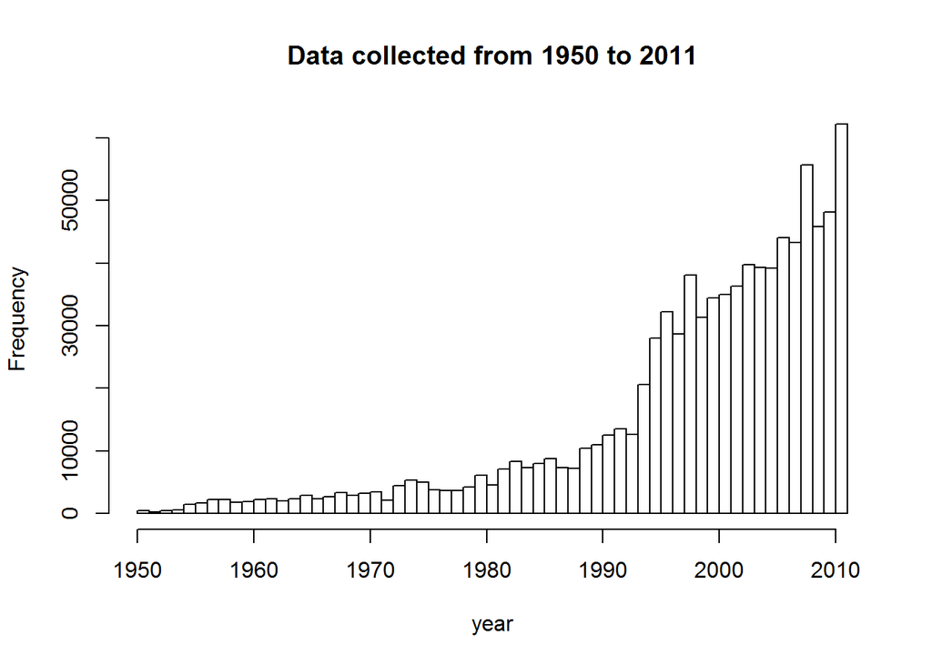

```r
health<- ddply(data, .(EVTYPE), summarize, INJURIES = sum(INJURIES),FATALITIES=sum(FATALITIES),na.rm=T)
data$year <- as.numeric(format(as.Date(data$BGN_DATE, format = "%m/%d/%Y %H:%M:%S"), "%Y"))
hist(data$year,xlab="year",main="Data collected from 1950 to 2011",breaks=60)
```

```r
fatalSub <- health[,c(1,3)]
injSub <- health[,1:2]
fatalities <- fatalSub[order(fatalSub$FATALITIES,decreasing = T),]
topTenFacilities <- head(fatalities, n=10)
injuries <- injSub[order(injSub$INJURIES,decreasing = T),]
topTenInjuries <- head(injuries, n= 10)
```

From the graph above, we see the lack of data from 1950 to 1994, and the highest amount of data available in 2011. Now, We need to process the PROPDMGEXP and CROPDMGEXP categories to calculate the damage done to the US in dollar. We do so by substitute B with 9, M with 6, K with 3, H with 2, and empty space with 0.

```r
data$PROPDMGEXP <- as.character(data$PROPDMGEXP)
data$PROPDMGEXP[toupper(data$PROPDMGEXP) == "B"] <- "9"
data$PROPDMGEXP[toupper(data$PROPDMGEXP) == "M"] <- "6"
data$PROPDMGEXP[toupper(data$PROPDMGEXP) == "K"] <- "3"
data$PROPDMGEXP[toupper(data$PROPDMGEXP) == "H"] <- "2"
data$PROPDMGEXP <- as.numeric(data$PROPDMGEXP)
data$PROPDMGEXP[is.na(data$PROPDMGEXP)] <- 0
data$propertyDamage <- data$PROPDMG * 10^data$PROPDMGEXP

data$CROPDMGEXP <- as.character(data$CROPDMGEXP)
data$CROPDMGEXP[toupper(data$CROPDMGEXP) == "B"] <- "9"
data$CROPDMGEXP[toupper(data$CROPDMGEXP) == "M"] <- "6"
data$CROPDMGEXP[toupper(data$CROPDMGEXP) == "K"] <- "3"
data$CROPDMGEXP[toupper(data$CROPDMGEXP) == "H"] <- "2"
data$CROPDMGEXP[toupper(data$CROPDMGEXP) == ""] <- "0"
data$CROPDMGEXP <- as.numeric(data$CROPDMGEXP)
data$CROPDMGEXP[is.na(data$CROPDMGEXP)] <- 0
data$cropDamage <- data$CROPDMG * 10^data$CROPDMGEXP
```

Now, we can extract the ten highest values from the data after calculating the sum for each event type.

```r
economy <- ddply(data, .(EVTYPE), summarize, propertyDamage = sum(propertyDamage),cropDamage=sum(cropDamage),na.rm=T)
property <- economy[order(economy$propertyDamage,decreasing = T),c(1,2)]
topTenPropertyDMG <- head(property, n=10)
crop <- economy[order(economy$cropDamage,decreasing = T),c(1,3)]
topTenCropDMG <- head(crop, n= 10)
```